# STAT 6600: Assignment 1

## Due: September 10, 2019

## Akeem Ajede

### Question 1(a)

Find the sample mean $\bar{x}$ and standard deviation $s$. Then compute the intervals [$\bar{x}-s, \bar{x}+s$], [$\bar{x}-2s, \bar{x}+2s$] and [$\bar{x}-3s, \bar{x}+3s$] and compute the percentage of sample values that fall within each interval.

### Solution

$\mathbf{Approach}$: Stem and Leaf

$(n+1)p=(97)\frac{1}{2}=48.5 = 48+\frac{1}{2}$,

The sample mean is located between the 48th and 49th integer.

$\hat{\pi}_{\frac{1}{2}}=(1-\frac{1}{2})x_{48}+(\frac{1}{2})x_{49}=(\frac{1}{2})16.6+(\frac{1}{2})16.7=16.65$

From sigma rule, $95\%$ of the data lies within $2s$ from $\mu$. Hence, $5\%$ of the data are beyond $2s$, which is approximately $96*5\%=4.8,$ (i.e., about 4 or 5 observations). From the 16th stem, 4 and 3 stems from the right and left tail, respectively will keep 4 observations beyond 2 standard deviations from the mean. By computing the average, $\frac{3+4}{2}=3.5=2\sigma,$ Thus, $\sigma=1.75$

$\mathbf{Intervals:}$

$[\bar{x} - s, \bar{x} + s] = [16.7 - 1.75, 16.7 + 1.75] = [15.0, 18.5]$ which contains 65 values $\approx 67.7\%$ of the data.

$[\bar{x} - 2s, \bar{x} + 2s] = [16.7 - 2(1.75), 16.7 + 2(1.75)] = [13.2, 20.2]$ which contains 91 values $\approx 94.7\%$ of the data.

$[\bar{x} - 3s, \bar{x} + 3s] = [16.7 - 3(1.75), 16.7 + 3(1.75)] = [11.45, 21.95]$ which contains 95 values $\approx 98.9\%$ of the data.

$\mathbf{Note:}$ The sample percentages computed approximately corresponds to the established proportions of a standard normal distribution.

### Question 1(b)

Find the minimum $x_{(1)}$ and the maximum $x_{(96)}$ order statistics, the 25th, 50th and 75th percentiles (also known as the 1st quartile $Q1$, the median $\tilde{x}$ and the third quartile $Q3$, respectively. Use the stem-and-leaf plot to do so. Also,find the interquartile range $IQR = Q3 - Q1$.

### Solution

$x_{(1)}=11.9$ and $x_{(96)}=22.1$,

$P_{25}=Q_1$

$p=\frac{25}{100}=\frac{1}{4}$, $(n+1)p=(97)\frac{1}{4}=22.25 = 22+\frac{1}{4}$,

$\hat{\pi}_{\frac{1}{4}}=(1-\frac{1}{4})x_{22}+(\frac{1}{4})x_{23}=(\frac{3}{4})15.3+(\frac{1}{4})15.4=15.3$

$P_{75}=Q_3$

$p=\frac{75}{100}=\frac{3}{4}$, $(n+1)p=(97)\frac{3}{4}=72.75 = 72+\frac{3}{4}$,

$\hat{\pi}_{\frac{3}{4}}=(1-\frac{3}{4})x_{72}+(\frac{3}{4})x_{73}=(\frac{3}{4})17.8+(\frac{1}{4})17.8=17.8$,

$IQR = Q_3-Q_1=17.8-15.3=2.5$

### Question 1(c)

Find the 5th and 95th percentiles $p_5$ and $p_{95}$

### Solution

$\mathbf{P_5}$

$\hat{\pi}_{\frac{1}{20}}=(1-\frac{1}{20})x_{4}+(\frac{1}{20})x_{5}=(\frac{19}{20})13.7+(\frac{1}{20})14.1=\mathbf{13.7}$

$\mathbf{P_{95}}$

$p=\frac{95}{100}=\frac{19}{20}$, $(n+1)p=(97)\frac{19}{20}=92.15=92+\frac{3}{20}$,

$\hat{\pi}_{\frac{19}{20}}=(1-\frac{19}{20})x_{92}+(\frac{19}{20})x_{93}=(\frac{1}{20})19.8+(\frac{19}{20})20.2=\mathbf{20.18}$

### Question 1(d)

Assuming that the data are from a normal population, and an expression for the maximum likelihood estimator of the CDF,

$$F_X(x)=\frac{1}{\sqrt{2\pi}\sigma}\int_{-\infty}^xexp\Big\{ -\frac{(t-\mu)^2}{2\sigma^2}\Big\}dt.$$

### Solution

Using the invariant property of MLEs, an estimate of the CDF is given as
$$F_X(x|\hat\theta)=\frac{1}{\sqrt{2\pi}\hat\sigma}\int_{-\infty}^xexp\Big\{ -\frac{(t-\hat\mu)^2}{2\hat\sigma^2}\Big\}dt,$$

where, $\hat\mu=\bar X=16.7$, and $\hat\sigma^2=\frac{\sum_{i=1}^{96}(x_i-\bar x)^2}{n}=\mathbf{3.396}$

### Question 1(e)

Use R to generate a histogram of the sample distribution with the “theoretical” pdf overlaid.

### Solution

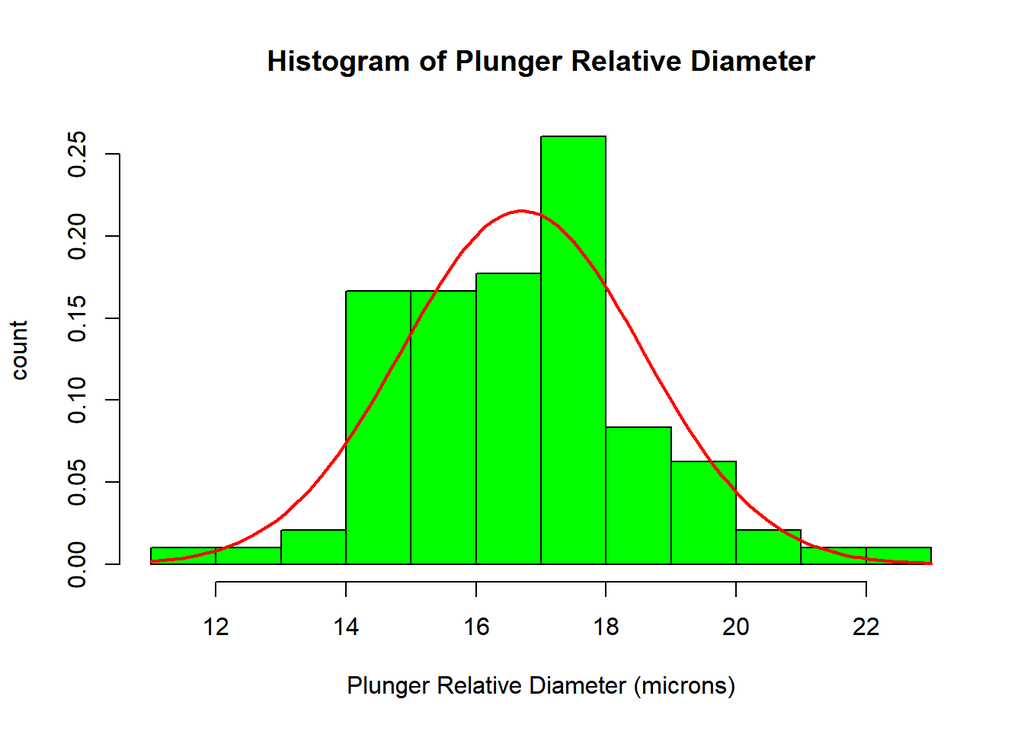

```r
Raw = read.table("Prob1InjectorPumps.txt", header = F)
y = Raw[order(Raw$V1),]
hist(y, prob = T, xlab = "Plunger Relative Diameter (microns)", ylab = "count", col = "green", main = "Histogram of Plunger Relative Diameter")
m <-mean(y);std <-sqrt(var(y))
curve(dnorm(x, mean=m, sd=std), col= 2, lwd=2, add=TRUE)
```

### Question 1(f)

Use R to generate the empirical CDF with the “theoretical” CDF overlaid.

### Solution

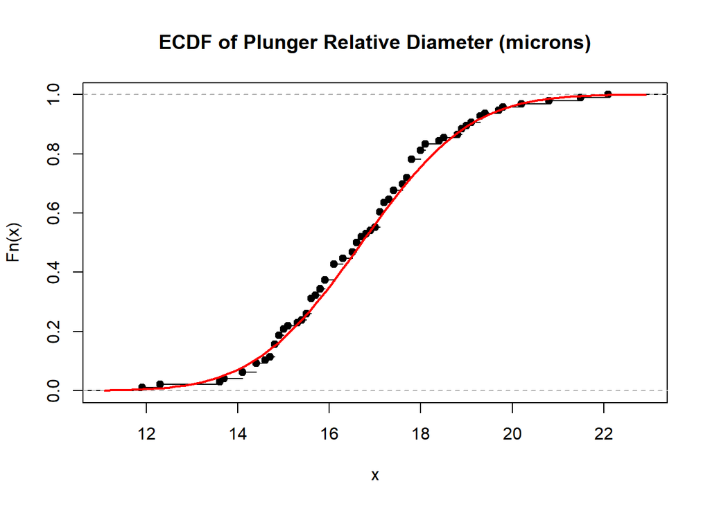

```r
plot(ecdf(y), main = "ECDF of Plunger Relative Diameter (microns)")
curve(pnorm(x, m, std), col= 2, lwd=2, add=TRUE)
```

### Question 1(g)

Use R to produce a normal QQ plot.

### Solution

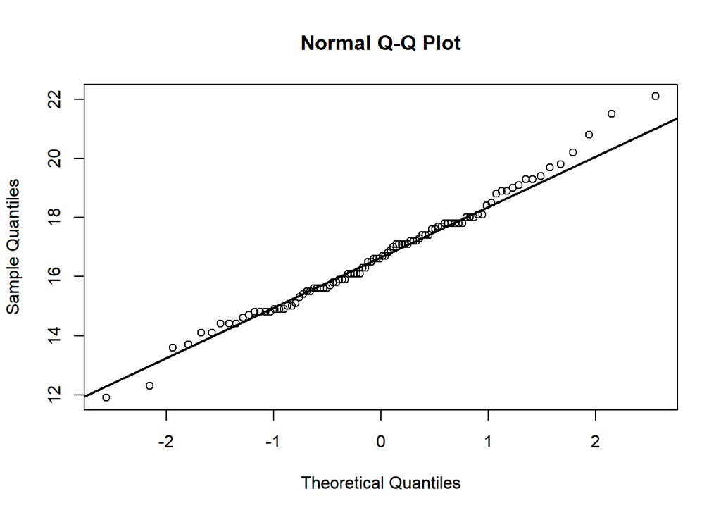

```r
qqnorm(y)
qqline(y, col = "black", lwd = 2)
```

### Question 1(h)

Does the data look like it came from a normal population?l

### Solution

From the normality plot (i.e., qq - plot), the data form an approximately straight line along the normality line. Hence, it is safe to conclude that the data came from a normal population.

### Question 1(i)

Recall that since $\bar{X} \approx N(\mu_{\bar{X}},\sigma^2_{\bar{X}}) = N(\mu, \frac{\sigma^2}{n}),$ the $SE(\hat{\mu})=\frac{s}{\sqrt{n}}$. Compute a $90\%$ confidence interval on the true mean plunger force.

### Solution

Interval: $\bar{x}\pm t_\frac{\alpha}{2},_{n-2} *\frac{S_n}{\sqrt{n}}$ = $16.706 \pm(-0.312)$,

$(16.394\leqslant \bar{x} \leqslant 17.018$

### Question 2(e)

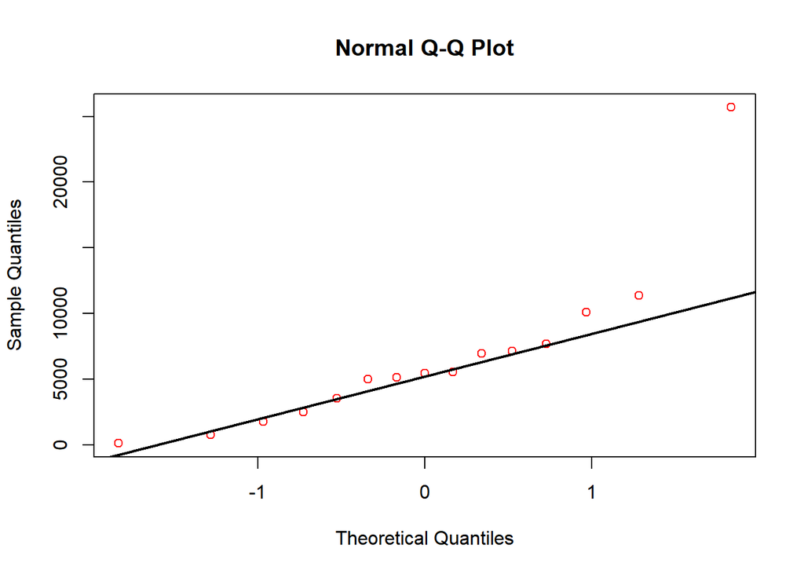

```r
q2 = c(106, 4972, 7140, 7661, 1776, 2471, 5550, 6959, 3541, 747, 5142, 25691, 11345, 10067, 5434)
qqnorm(q2, col = 2)
qqline(q2, col = "black", lwd = 2)
```

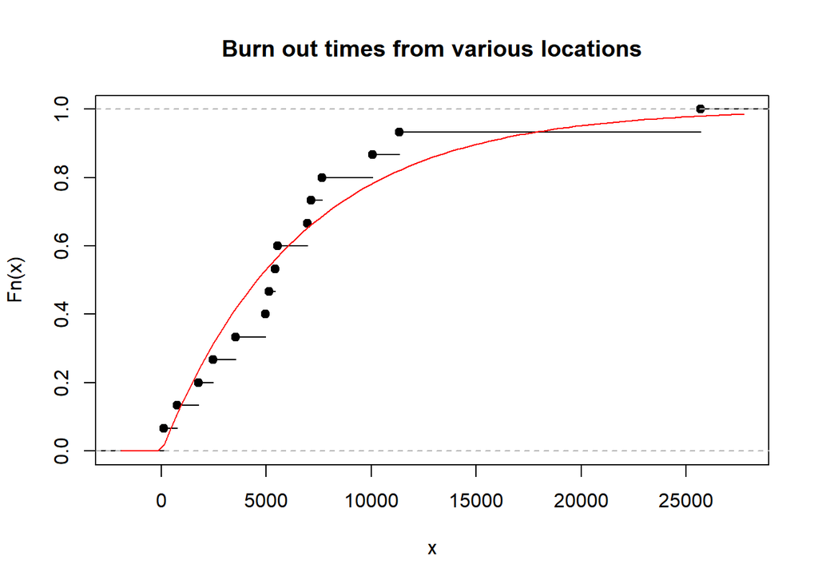

```r
plot(ecdf(q2), main = "Burn out times from various locations")
curve(pexp(x,0.000152), add=TRUE, col= 2)
```